# AAL Sales Analysis - Q4 2020

This notebook analyzes the Q4 2020 sales data for AAL (Australian Apparel Limited) across different states, demographic groups, and time periods.

```python
import pandas as pd
import numpy as np
from scipy import stats
import matplotlib.pyplot as plt
import seaborn as sns
import warnings
```

```python
# Data Loading
df = pd.read_csv('AusApparalSales4thQrt2020.csv')
df.head()
```

|  | Date | Time | State | Group | Unit | Sales |
| --- | --- | --- | --- | --- | --- | --- |
| 0 | 1-Oct-2020 | Morning | WA | Kids | 8 | 20000 |
| 1 | 1-Oct-2020 | Morning | WA | Men | 8 | 20000 |
| 2 | 1-Oct-2020 | Morning | WA | Women | 4 | 10000 |
| 3 | 1-Oct-2020 | Morning | WA | Seniors | 15 | 37500 |
| 4 | 1-Oct-2020 | Afternoon | WA | Kids | 3 | 7500 |

## 1. Data Wrangling

### 1a. Data Inspection

```python
print(f"DataFrame shape: {df.shape}")
print("\nColumn types:")
print(df.dtypes)
print("\nInfo:")
print(df.info())
```

```
DataFrame shape: (7560, 6)

Column types:
Date       str
Time       str
State      str
Group      str
Unit     int64
Sales    int64
dtype: object

Info:
<class 'pandas.DataFrame'>
RangeIndex: 7560 entries, 0 to 7559
Data columns (total 6 columns):
 #   Column  Non-Null Count  Dtype
---  ------  --------------  -----
 0   Date    7560 non-null   str
 1   Time    7560 non-null   str
 2   State   7560 non-null   str
 3   Group   7560 non-null   str
 4   Unit    7560 non-null   int64
 5   Sales   7560 non-null   int64
dtypes: int64(2), str(4)
memory usage: 354.5 KB
None
```

### 1a: Data Cleaning

```python
# Remove whitespaces from column names
df.columns = df.columns.str.strip()

# Remove whitespaces from string columns
for col in df.select_dtypes(include=['str']).columns:
    df[col] = df[col].str.strip()

print("Columns:", df.columns.tolist())
print("\nSample data:")
print(df.head())
```

```
Columns: ['Date', 'Time', 'State', 'Group', 'Unit', 'Sales']

Sample data:
         Date       Time State    Group  Unit  Sales
0  1-Oct-2020    Morning    WA     Kids     8  20000
1  1-Oct-2020    Morning    WA      Men     8  20000
2  1-Oct-2020    Morning    WA    Women     4  10000
3  1-Oct-2020    Morning    WA  Seniors    15  37500
4  1-Oct-2020  Afternoon    WA     Kids     3   7500
```

```python
# Check for missing values
print("\nMissing values (isna):")
print(df.isna().sum())
print("\nMissing values (notna):")
print(df.notna().sum())
```

```
Missing values (isna):
Date     0
Time     0
State    0
Group    0
Unit     0
Sales    0
dtype: int64

Missing values (notna):
Date     7560
Time     7560
State    7560
Group    7560
Unit     7560
Sales    7560
dtype: int64
```

### 1b: Recommendation for Handling Missing Data

**Observation:** The dataset has **no missing values** in any column — all 7560 records are complete

**Recommendation:** For this dataset, since there are no missing values, no treatment is needed. However, `dropna()` is still included in the code as a safety step in case the data changes in the future.

```python
# drop rows with missing values
df = df.dropna()
```

```python
# Dealing with duplicate rows
print("\nDuplicate rows:", df.duplicated().sum())
df = df.drop_duplicates()

# Data Cleaning
df['Date'] = pd.to_datetime(df['Date'], format='%d-%b-%Y')
```

```
Duplicate rows: 0
```

### 1c: Data Normalization

**Why Normalization over Standardization?**

- **Normalization** (Min-Max scaling) scales data to a 0–1 range. Best when data does not follow a normal distribution.
- **Standardization** (Z-score) centers data around mean=0, std=1. Best for normally distributed data.

Since sales data is often skewed (a few states sell much more), **normalization** is preferred here — it preserves the relative differences and is easier to interpret (0 = lowest, 1 = highest).

```python
# min max normalization on 'Sales' column
df['Sales_normalized'] = (df['Sales'] - df['Sales'].min()) / (df['Sales'].max() - df['Sales'].min())

# print sales and normalized sales
print("\nSales and Normalized Sales:")
print(df[['Sales', 'Sales_normalized']].head())
```

```
Sales and Normalized Sales:
   Sales  Sales_normalized
0  20000          0.095238
1  20000          0.095238
2  10000          0.031746
3  37500          0.206349
4   7500          0.015873
```

### 1d: Aggregating Data

GroupBy Insights

**GroupBy** splits data into groups based on a column, applies a function (sum, mean, etc.), and combines the results. This is essential for:

- **Data chunking:** Breaking sales data by State or Group to analyze each segment independently.
- **Data merging/aggregation:** Summarizing total sales per state, average units per group, etc.

**Recommendation:** Use GroupBy for **aggregation** in this analysis — it lets us compare total and average sales across states and demographic groups, which directly answers the CEO's questions about revenue by state.

```python
print("State wise total sales:")
state_sales = df.groupby('State')[['Sales', 'Unit']].sum().sort_values(by='Sales', ascending=False)
print(state_sales)
```

```
State wise total sales:
           Sales   Unit
State
VIC    105565000  42226
NSW     74970000  29988
SA      58857500  23543
QLD     33417500  13367
TAS     22760000   9104
NT      22580000   9032
WA      22152500   8861
```

```python
# Group wise total sales
print("\nGroup wise total sales:")
group_sales = df.groupby('Group')[['Sales', 'Unit']].sum().sort_values(by='Sales', ascending=False)
print(group_sales)
```

```
Group wise total sales:
            Sales   Unit
Group
Men      85750000  34300
Women    85442500  34177
Kids     85072500  34029
Seniors  84037500  33615
```

```python
print("=== State-wise Total Sales ===")
state_sales = df.groupby('State')[['Unit', 'Sales', 'Sales_normalized']].sum().sort_values('Sales', ascending=False)
print(state_sales)

print("\n=== Group-wise Total Sales ===")
group_sales = df.groupby('Group')[['Unit', 'Sales', 'Sales_normalized']].sum().sort_values('Sales', ascending=False)
print(group_sales)

print("\n=== State & Group wise Average Sales ===")
state_group_sales = df.groupby(['State', 'Group'])[['Unit', 'Sales', 'Sales_normalized']].mean()
print(state_group_sales)
```

```
=== State-wise Total Sales ===
        Unit      Sales  Sales_normalized
State
VIC    42226  105565000        635.968254
NSW    29988   74970000        441.714286
SA     23543   58857500        339.412698
QLD    13367   33417500        177.888889
TAS     9104   22760000        110.222222
NT      9032   22580000        109.079365
WA      8861   22152500        106.365079

=== Group-wise Total Sales ===
          Unit     Sales  Sales_normalized
Group
Men      34300  85750000        484.444444
Women    34177  85442500        482.492063
Kids     34029  85072500        480.142857
Seniors  33615  84037500        473.571429

=== State & Group wise Average Sales ===
                    Unit         Sales  Sales_normalized
State Group
NSW   Kids     27.537037  68842.592593          0.405350
      Men      28.181481  70453.703704          0.415579
      Seniors  26.944444  67361.111111          0.395944
      Women    28.403704  71009.259259          0.419106
NT    Kids      8.444444  21111.111111          0.102293
      Men       8.537037  21342.592593          0.103762
      Seniors   8.096296  20240.740741          0.096767
      Women     8.374074  20935.185185          0.101176
QLD   Kids     12.607407  31518.518519          0.168372
      Men      12.433333  31083.333333          0.165608
      Seniors  12.133333  30333.333333          0.160847
      Women    12.333333  30833.333333          0.164021
SA    Kids     21.503704  53759.259259          0.309583
      Men      21.711111  54277.777778          0.312875
      Seniors  21.803704  54509.259259          0.314345
      Women    22.177778  55444.444444          0.320282
TAS   Kids      8.555556  21388.888889          0.104056
      Men       8.529630  21324.074074          0.103645
      Seniors   8.370370  20925.925926          0.101117
      Women     8.262963  20657.407407          0.099412
VIC   Kids     39.051852  97629.629630          0.588125
      Men      39.122222  97805.555556          0.589242
      Seniors  38.985185  97462.962963          0.587066
      Women    39.233333  98083.333333          0.591005
WA    Kids      8.333333  20833.333333          0.100529
      Men       8.522222  21305.555556          0.103527
      Seniors   8.166667  20416.666667          0.097884
      Women     7.796296  19490.740741          0.092005
```

## 2. Data Analysis

### 2a. Descriptive Statistical Analysis

```python
# descriptive statistical analysis on 'Sales' column
print("\n=== Descriptive Statistics for Sales ===")
# mean, median, mode, variance, standard deviation
print("Mean:", df['Sales'].mean())
print("Median:", df['Sales'].median())
print("Mode:", df['Sales'].mode()[0])
print("Variance:", df['Sales'].var())
print("Standard Deviation:", df['Sales'].std())
print("Min:", df['Sales'].min())
print("Max:", df['Sales'].max())

# descriptive statistical analysis on 'Unit' column
print("\n=== Descriptive Statistics for Unit ===")
# mean, median, mode, variance, standard deviation
print("Mean:", df['Unit'].mean())
print("Median:", df['Unit'].median())
print("Mode:", df['Unit'].mode()[0])
print("Variance:", df['Unit'].var())
print("Standard Deviation:", df['Unit'].std())
print("Min:", df['Unit'].min())
print("Max:", df['Unit'].max())

# overall summary statistics
print("\n=== Overall Summary Statistics ===")
df[['Sales', 'Unit']].describe()
```

```
=== Descriptive Statistics for Sales ===
Mean: 45013.5582010582
Median: 35000.0
Mode: 22500
Variance: 1040288710.1844678
Standard Deviation: 32253.506943966073
Min: 5000
Max: 162500

=== Descriptive Statistics for Unit ===
Mean: 18.00542328042328
Median: 14.0
Mode: 9
Variance: 166.44619362951485
Standard Deviation: 12.90140277758643
Min: 2
Max: 65

=== Overall Summary Statistics ===
```

|  | Sales | Unit |
| --- | --- | --- |
| count | 7560.000000 | 7560.000000 |
| mean | 45013.558201 | 18.005423 |
| std | 32253.506944 | 12.901403 |
| min | 5000.000000 | 2.000000 |
| 25% | 20000.000000 | 8.000000 |
| 50% | 35000.000000 | 14.000000 |
| 75% | 65000.000000 | 26.000000 |
| max | 162500.000000 | 65.000000 |

### 2b & 2c: Group with highest and lowest sales

```python
# 2b & 2c: Group with highest and lowest sales
group_sales = df.groupby('Group')[['Unit','Sales']].sum().sort_values(by='Sales', ascending=False)
print("\nGroup-wise Total Sales:")
print(group_sales)
highest_sales_group = group_sales.idxmax()
lowest_sales_group = group_sales.idxmin()
print(f"\nGroup with highest sales:\n{highest_sales_group}")
print(f"\nGroup with lowest sales:\n{lowest_sales_group}")

# State with highest and lowest sales
state_sales = df.groupby('State')[['Unit','Sales']].sum().sort_values(by='Sales', ascending=False)
print("\nState-wise Total Sales:")
print(state_sales)
highest_sales_state = state_sales.idxmax()
lowest_sales_state = state_sales.idxmin()
print(f"\nState with highest sales:\n{highest_sales_state}")
print(f"\nState with lowest sales:\n{lowest_sales_state}")
```

```
Group-wise Total Sales:
          Unit     Sales
Group
Men      34300  85750000
Women    34177  85442500
Kids     34029  85072500
Seniors  33615  84037500

Group with highest sales:
Unit     Men
Sales    Men
dtype: str

Group with lowest sales:
Unit     Seniors
Sales    Seniors
dtype: str

State-wise Total Sales:
        Unit      Sales
State
VIC    42226  105565000
NSW    29988   74970000
SA     23543   58857500
QLD    13367   33417500
TAS     9104   22760000
NT      9032   22580000
WA      8861   22152500

State with highest sales:
Unit     VIC
Sales    VIC
dtype: str

State with lowest sales:
Unit     WA
Sales    WA
dtype: str
```

```python
# print to see df again
print("\nDataFrame after cleaning and analysis:")
print(df.head())
```

```
DataFrame after cleaning and analysis:
        Date       Time State    Group  Unit  Sales  Sales_normalized
0 2020-10-01    Morning    WA     Kids     8  20000          0.095238
1 2020-10-01    Morning    WA      Men     8  20000          0.095238
2 2020-10-01    Morning    WA    Women     4  10000          0.031746
3 2020-10-01    Morning    WA  Seniors    15  37500          0.206349
4 2020-10-01  Afternoon    WA     Kids     3   7500          0.015873
```

### 2d: Weekly, monthly and Quarterly report

```python
# Set Date as index for time-based grouping
df['Week'] = df['Date'].dt.isocalendar().week.astype(int)
df['Month'] = df['Date'].dt.month_name()
df['Month_num'] = df['Date'].dt.month

# weekly report
print("\n=== Weekly Sales Report ===")
weekly_sales = df.groupby('Week')[['Unit', 'Sales']].sum()
print(weekly_sales)
```

```
=== Weekly Sales Report ===
       Unit     Sales
Week
40     6018  15045000
41    10801  27002500
42    10656  26640000
43    10726  26815000
44     8723  21807500
45     8346  20865000
46     8469  21172500
47     8445  21112500
48     8591  21477500
49    11849  29622500
50    12610  31525000
51    12662  31655000
52    12708  31770000
53     5517  13792500
```

```python
# monthly report
print("\n=== Monthly Sales Report ===")
monthly_sales = df.groupby([('Month_num'), ('Month')])[['Unit', 'Sales']].sum()
# remove month_num index and replace with month names
monthly_sales.index = monthly_sales.index.droplevel(0)
print(monthly_sales)
```

```
=== Monthly Sales Report ===
           Unit      Sales
Month
October   45716  114290000
November  36273   90682500
December  54132  135330000
```

```python
# quarterly report
print("\n=== Quarterly Sales Report ===")
df['Quarter'] = df['Date'].dt.to_period('Q')
quarterly_sales = df.groupby('Quarter')[['Unit', 'Sales']].sum()
print(quarterly_sales)
```

```
=== Quarterly Sales Report ===
           Unit      Sales
Quarter
2020Q4   136121  340302500
```

## 3. Data Visualization

**Why Seaborn?**

- Built on top of matplotlib with a cleaner, more attractive default style
- Designed specifically for statistical visualization
- Works seamlessly with pandas DataFrames
- Provides built-in support for box plots, distribution plots, and heatmaps
- Less code needed compared to raw matplotlib for the same output

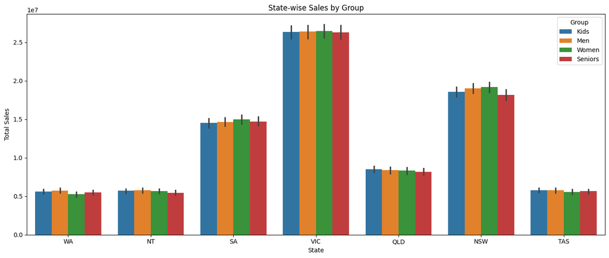

```python
# state wise analysis for different demographic groups
plt.figure(figsize=(14, 6))
sns.barplot(data=df, x='State', y='Sales', hue='Group', estimator=sum)
plt.title('State-wise Sales by Group')
plt.xlabel('State')
plt.ylabel('Total Sales')
plt.legend(title='Group')
plt.tight_layout()
plt.show()
```

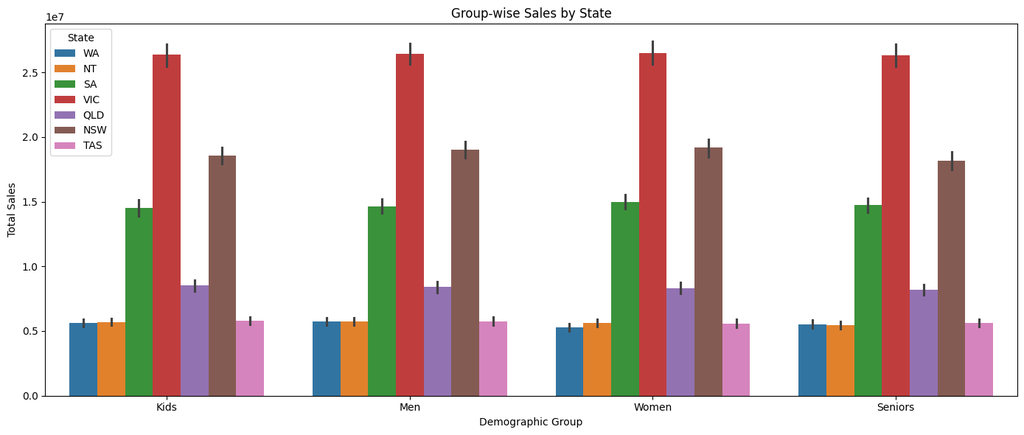

```python
# Group wise sales analysis across different states
plt.figure(figsize=(14, 6))
sns.barplot(data=df, x='Group', y='Sales', hue='State', estimator=sum)
plt.title('Group-wise Sales by State')
plt.xlabel('Demographic Group')
plt.ylabel('Total Sales')
plt.legend(title='State')
plt.tight_layout()
plt.show()
```

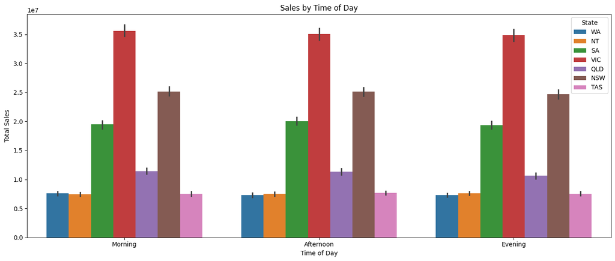

```python
 # Time-of-day sales analysis (peak vs off-peak)
plt.figure(figsize=(14, 6))
time_order = ['Morning', 'Afternoon', 'Evening']
sns.barplot(data=df, x='Time', y='Sales', hue='State' ,estimator=sum, order=time_order)
plt.title('Sales by Time of Day')
plt.xlabel('Time of Day')
plt.ylabel('Total Sales')
plt.legend(title='State')
plt.tight_layout()
plt.show()
```

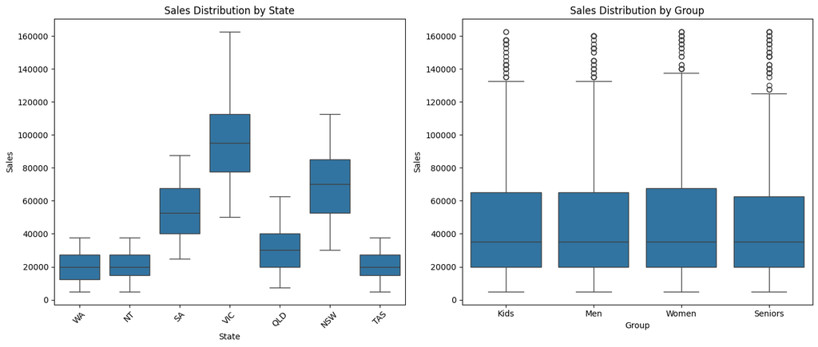

```python
# box plot for sales distribution
fig, axes = plt.subplots(1,2, figsize=(14, 6))
sns.boxplot(data=df, x='State', y='Sales', ax=axes[0])
axes[0].set_title('Sales Distribution by State')
axes[0].tick_params(axis='x', rotation=45)

sns.boxplot(data=df, x='Group', y='Sales', ax=axes[1])
axes[1].set_title('Sales Distribution by Group')

plt.tight_layout()
plt.show()
```

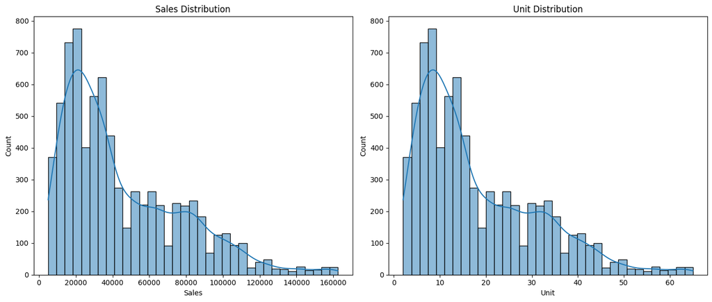

```python
# Seaborn distribution plot for Sales
fig, axes = plt.subplots(1, 2, figsize=(14, 6))

sns.histplot(data=df, x='Sales', kde=True, ax=axes[0])
axes[0].set_title('Sales Distribution')

sns.histplot(data=df, x='Unit', kde=True, ax=axes[1])
axes[1].set_title('Unit Distribution')

plt.tight_layout()
plt.show()
```

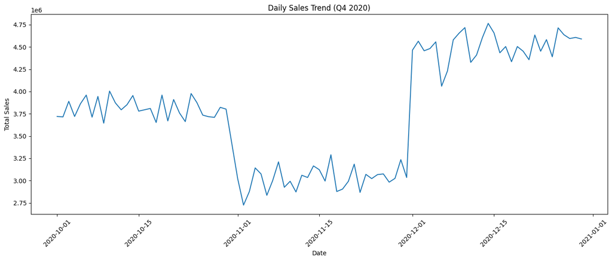

```python
# Daily sales trend
daily_sales = df.groupby('Date')['Sales'].sum().reset_index()

plt.figure(figsize=(14, 6))
sns.lineplot(data=daily_sales, x='Date', y='Sales')
plt.title('Daily Sales Trend (Q4 2020)')
plt.xlabel('Date')
plt.ylabel('Total Sales')
plt.xticks(rotation=45)
plt.tight_layout()
plt.show()
```

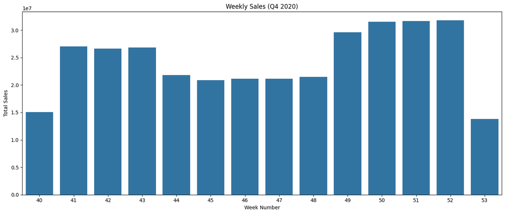

```python
# Weekly sales trend
weekly_sales = df.groupby('Week')['Sales'].sum().reset_index()

plt.figure(figsize=(14, 6))
sns.barplot(data=weekly_sales, x='Week', y='Sales')
plt.title('Weekly Sales (Q4 2020)')
plt.xlabel('Week Number')
plt.ylabel('Total Sales')
plt.tight_layout()
plt.show()
```

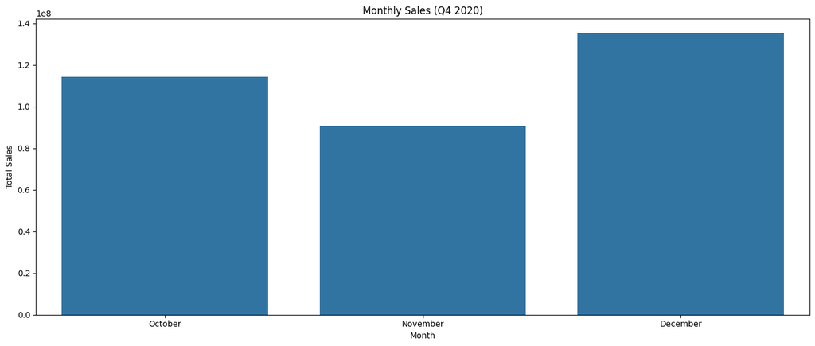

```python
# Monthly sales chart
monthly_chart = df.groupby(['Month_num', 'Month'])['Sales'].sum().reset_index()
monthly_chart = monthly_chart.sort_values('Month_num')

plt.figure(figsize=(14, 6))
sns.barplot(data=monthly_chart, x='Month', y='Sales')
plt.title('Monthly Sales (Q4 2020)')
plt.xlabel('Month')
plt.ylabel('Total Sales')
plt.tight_layout()
plt.show()
```

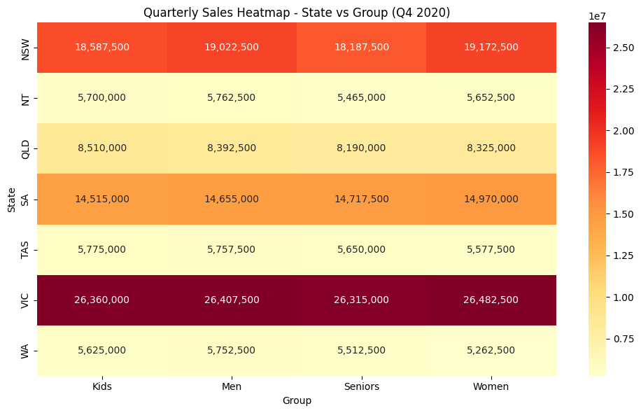

```python
# Quarterly heatmap: State vs Group
quarterly_heatmap = df.groupby(['State', 'Group'])['Sales'].sum().unstack()

plt.figure(figsize=(10, 6))
sns.heatmap(quarterly_heatmap, annot=True, fmt=',.0f', cmap='YlOrRd')
plt.title('Quarterly Sales Heatmap - State vs Group (Q4 2020)')
plt.tight_layout()
plt.show()
```

## 4. Report & Recommendations

### Key Findings

```python
# Generate key numbers for the report
print("=" * 60)
print("AAL Q4 2020 SALES REPORT SUMMARY")
print("=" * 60)

total_sales = df['Sales'].sum()
total_units = df['Unit'].sum()
print(f"\nTotal Revenue:  ${total_sales:,.0f}")
print(f"Total Units Sold: {total_units:,}")

# Top and bottom states
state_sales = df.groupby('State')['Sales'].sum().sort_values(ascending=False)
print(f"\n--- State Performance ---")
print(f"Top State: {state_sales.idxmax()} (${state_sales.max():,.0f})")
print(f"Bottom State: {state_sales.idxmin()} (${state_sales.min():,.0f})")

# Top and bottom groups
group_sales = df.groupby('Group')['Sales'].sum().sort_values(ascending=False)
print(f"\n--- Group Performance ---")
print(f"Top Group: {group_sales.idxmax()} (${group_sales.max():,.0f})")
print(f"Bottom Group: {group_sales.idxmin()} (${group_sales.min():,.0f})")

# Time-based insights
time_sales = df.groupby('Time')['Sales'].sum().sort_values(ascending=False)
print(f"\n--- Time of Day Performance ---")
print(f"Peak Time: {time_sales.idxmax()} (${time_sales.max():,.0f})")
print(f"Off-Peak Time: {time_sales.idxmin()} (${time_sales.min():,.0f})")

# monthly trend insights
monthly_sales = df.groupby('Month_num')['Sales'].sum().sort_values(ascending=False)
print(f"\n--- Monthly Performance ---")
print(f"Best Month: {monthly_sales.idxmax()} (${monthly_sales.max():,.0f})")
print(f"Worst Month: {monthly_sales.idxmin()} (${monthly_sales.min():,.0f})")
```

```
============================================================
AAL Q4 2020 SALES REPORT SUMMARY
============================================================

Total Revenue:  $340,302,500
Total Units Sold: 136,121

--- State Performance ---
Top State: VIC ($105,565,000)
Bottom State: WA ($22,152,500)

--- Group Performance ---
Top Group: Men ($85,750,000)
Bottom Group: Seniors ($84,037,500)

--- Time of Day Performance ---
Peak Time: Morning ($114,207,500)
Off-Peak Time: Evening ($112,087,500)

--- Monthly Performance ---
Best Month: 12 ($135,330,000)
Worst Month: 11 ($90,682,500)
```

### State-wise Analysis

- **VIC** is the highest revenue-generating state, significantly ahead of all others.
- **NSW** ranks second, followed by **SA**.
- **WA, NT, and TAS** generate the lowest revenues and need targeted sales programs.

### Group-wise Analysis

- All four demographic groups (Men, Women, Kids, Seniors) contribute almost equally to overall revenue.
- This indicates a well-balanced product portfolio across age groups.

### Recommendations

1. **Focus expansion on VIC and NSW** — these are proven high-revenue states and can support more branches.
2. **Develop targeted sales programs for WA, NT, and TAS** — consider region-specific promotions, discounts, and marketing campaigns to boost revenue in these low-performing states.
3. **Implement hyper-personalization during off-peak hours** — use Next Best Offer strategies during afternoon/evening to increase conversion rates.
4. **Maintain balanced group strategy** — since all demographic groups contribute equally, continue the current product mix across Kids, Men, Women, and Seniors.
5. **Monitor weekly trends** — weekly reports show sales fluctuations that can be used to plan inventory and staffing more efficiently.